# 自由业者

## 和

## 全职工作

## 的

## 💘 血泪经验 💔

By Cliff Chew, 2025

# 为什么这个主题？

- 越来越多人选择远距工作、自雇接案、甚至全职当自由工作者
- 「梦想中的生活」：没有老板、时间自由、收入弹性
- 分享自己在自由接案和全职工作的喜怒哀乐

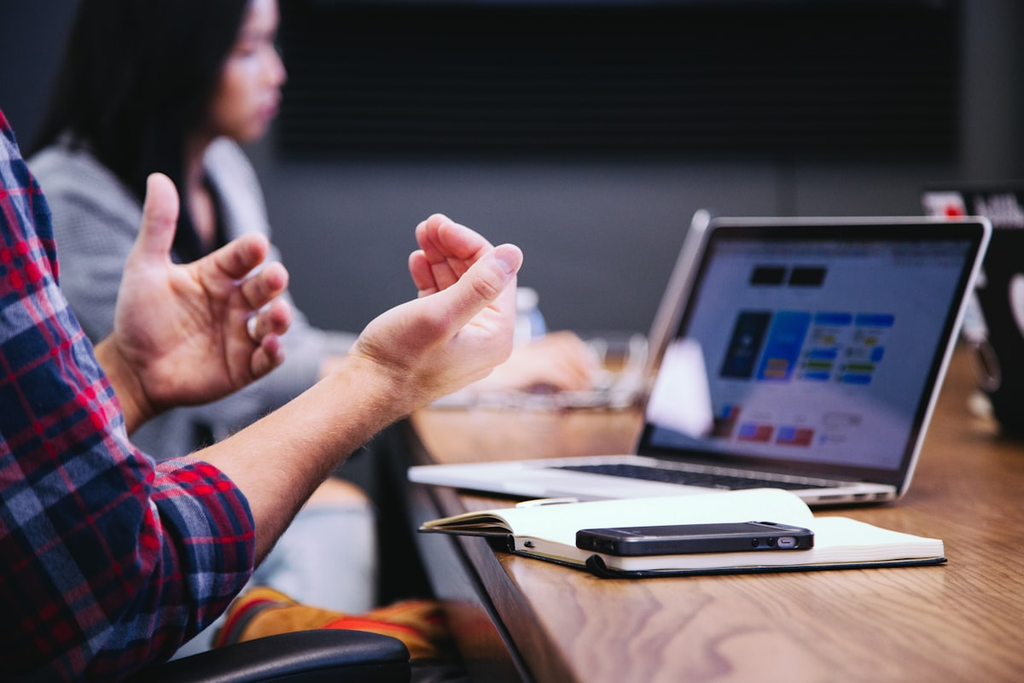

▲ 自由工作：表面是海边笔电，实则是日夜奔波

By Cliff Chew, 2025

# 我的背景

- ['09-'12] NUS : Econs Undergrad / Post-grad
- ['12-'14] NUS : Research Assistant ( Sociology )
- ['14-'16] Some Boring Non-Tech Jobs
- ['16-'19] Carousell : Digital Marketing Data Analyst
- ['19-'21] Grab : Senior Fraud Analyst
- ['21-'25] Freelance : Analytics Trainer / Consultant
- ['25+] Tech In Asia : Lead Data Analyst

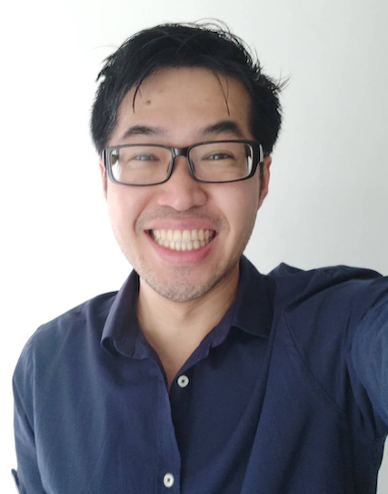

By Cliff Chew, 2025

# 我为什么想当自由工作者？

## 空间

- 📚 学习 ：公司内部受限
- 💰 收入 ：一份工，一份钱
- 🔥 挑战 ：想挑战自己的极限

## 自由

- 🕒 时间 : 选择几点上下班
- 🎯 项目 : 想挑战不同层面
- 🏝️ 地点 : 丰富人生

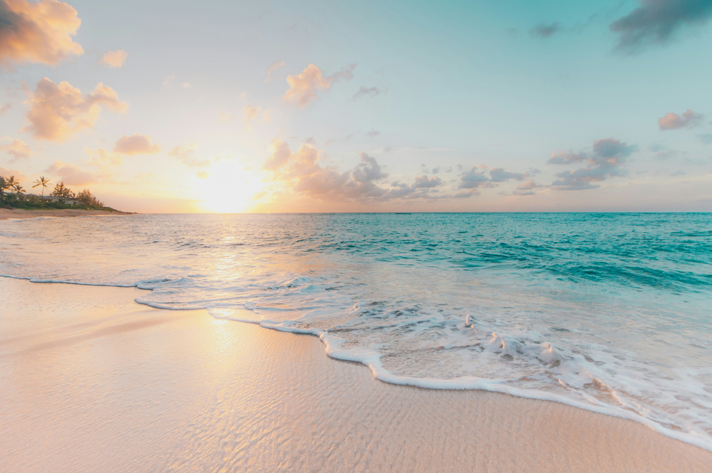

▲ 自由的象征

By Cliff Chew, 2025

# 我的自由工作经历

## 试水温

- 保留了Grab 现有的全职工作
- Part-time Bootcamp 导师

## 转自由

- 教学间顾问
- 教学 : 企业内部基础数据的培训
- 顾问 ：开始接到不同的案子

## 三年后

- 相辅相成
- 扩展自己的人脉，自我行销
- 自己想做的 side projects

By Cliff Chew, 2025

# 自我定位

## Freelancer

- 有n 老板
- 比较没有保障和福利的短期工
- 工作内容比较多元化
- 比较有弹性

## Solopreneur

- 自己推产品
- 没有老板，只有用户
- 工程师比较容易的跑到

## Self-employed

- 请人处理事情
- 和其他公司合作
- 有自己的产品或服务

By Cliff Chew, 2025

# 三年来的项目

## 收钱的

- Product Analytics - 东南亚的新创
- Brand Analytics - 新加坡的中小型企业
- Training - Coding & Analytics Instructor / 台湾Alpha Camp

## 好玩的

- [新加坡国宅的分析](https://sg-housing.onrender.com/sg-public-home-trends)
- [新加坡国图书馆的网页](https://sg-lib-books.web.app/dashboard)

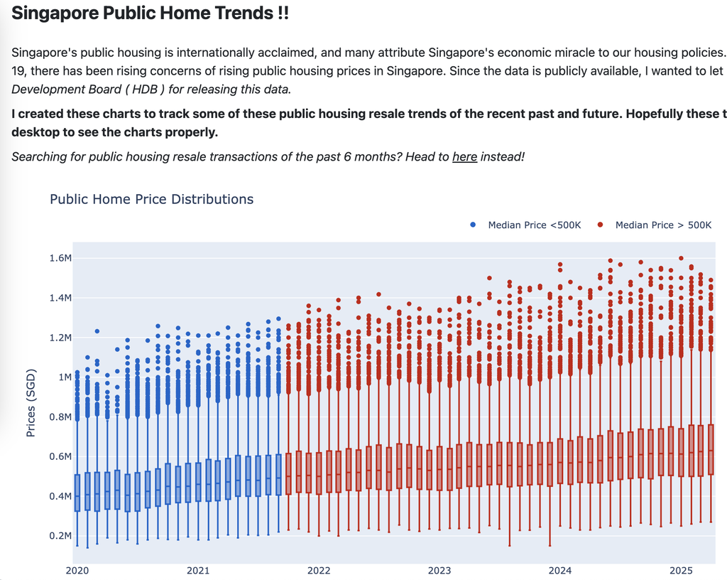

▲ 新加坡国宅的走向

[figure not shown]

▲ 太想念书的结果

By Cliff Chew, 2025

# 惨烈的经验

## 没收到钱

- 八个月的后段项目
- 不同的洽谈proposal

## 来者不拒

- 一个老板到 n 个老板
- 一周七天，一天十二小时
- 没有闲暇的项目

## 技不如人

- 网上爬虫
- 架起云端资料库
- 架起production predictive models
- 深入的AB Testing

By Cliff Chew, 2025

# 为什么又转全职?

## 变化

- 稳定收入
- 公司福利
- 带小团队
- 同僚商讨
- 主管想法

## 不变

- 自由空间
- 学习空间

By Cliff Chew, 2025

# 我适合当自由工作者么？

## 市场

- 设定主要顾客群
- 自我市场定位

## 能力

- 能执行一套完整产品的技术？
- 愿意行销？有把握找到顾客吗？
- 愿意接触不同领域？

## 条件

- 抵抗收入不稳定
- 自我规律

## 目标

- 对现有工作老板不满？
- 人生必达成执的目标？

By Cliff Chew, 2025

# 一定要转自由工作者吗？

- 换的工作
- 和主管商讨
- 兼差，斜杠
- 自我提升

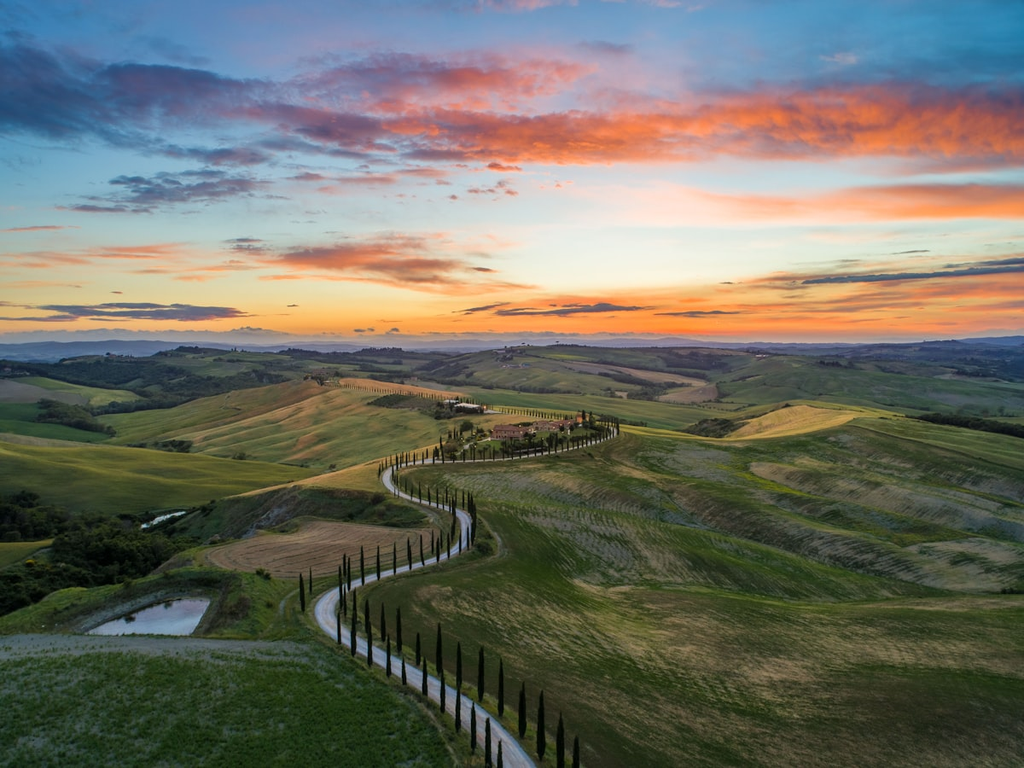

▲ 自由工作：真的需要吗？

By Cliff Chew, 2025

# 综合自由职业者的优缺点

## 优点

- 选择项目的灵活性
- 控制工作时间和地点
- 多样化的机会
- 可以做自己感兴趣的项目
- 高收入潜力

## 缺点

- 收入不稳定
- 没有公司福利（保险，有薪假）
- 处理所有行政工作（税务，合约）
- 孤独感
- 寻找新客户的压力

By Cliff Chew, 2025

# 最后几句让大家参考

## 要什么

金钱，自由，荣誉

## 能做什么

分析，编程，设计

## 愿意付出什么

行销，收入不稳定，不断学习

## 市场要什么

市场需求，大环境的变动

By Cliff Chew, 2025

# 感谢大家的聆听！

## 我的LinkedIn

[figure not shown]

By Cliff Chew, 2025